# Project: No show appointment of medical patients in Brazil

## Introduction

In this project i will be analyzing data associated with patients not showing up on their scheduled date of appointment based on some independent variables

This dataset collects information from 100k medical appointments in Brazil and is focused on the question of whether or not patients show up for their appointment. A number of characteristics about the patient are included in each row. ● ‘ScheduledDay’ tells us on what day the patient set up their appointment. ● ‘Neighborhood’ indicates the location of the hospital. ● 'Gender' indicates the sex of the patients ● 'Age' indicates the age of the patients ● 'SMS-received' indicates whether or not a patients received a scholarship or not ● ‘Scholarship’ indicates whether or not the patient is enrolled in Brasilian welfare program Bolsa Família. ● 'No-show': indicates whether a patient shows for an appointment or not; it says ‘No’ if the patient showed up to their appointment, and ‘Yes’ if they did not show up.

In particular, i am interested in finding the trends among the patients who showed up for their appointments, and how they differed from the patients who didn't show up.

# QUESTION WE CAN ASK ABOUT THE DATA SET

(1) Is there an association between gender and the patient showing for appointments or not? (i.e. does being a male or female have any effect on patients showing for their appointments

(2) Is there a relationship between age with the patient showing or not for appointment? (i.e. does being in certain age group (e.g. youths, adults, middle age, and old adults) have any effect on patients showing for their analysis.

(3) Is there a relationship between sms received with the patient showing or not for appointment? (i.e. does sms_received by the patients, reminding them for their appointments have any effect of patients showing up for their analysis).

(4) Is there a relationship between scholarship with the patient showing or not for appointment? (i.e. does awarding a patients scholarship have any effect of patients showing up for their analysis).

```python
# importing packages to be used for this analysis
import numpy as np
import pandas as pd
import matplotlib.pyplot as plt
import seaborn as sns
%matplotlib inline
```

## Data Wrangling

### General Properties

```python
# Load your data and print out a few lines.

#loading dataset 'No-show appointments'
df=pd.read_csv('noshowappointments-kagglev2-may-2016.csv')
df.head()
```

|  | PatientId | AppointmentID | Gender | ScheduledDay | AppointmentDay | Age | Neighbourhood | Scholarship | Hipertension | Diabetes | Alcoholism | Handcap | SMS_received | No-show |
| --- | --- | --- | --- | --- | --- | --- | --- | --- | --- | --- | --- | --- | --- | --- |
| 0 | 2.987250e+13 | 5642903 | F | 2016-04-29T18:38:08Z | 2016-04-29T00:00:00Z | 62 | JARDIM DA PENHA | 0 | 1 | 0 | 0 | 0 | 0 | No |
| 1 | 5.589978e+14 | 5642503 | M | 2016-04-29T16:08:27Z | 2016-04-29T00:00:00Z | 56 | JARDIM DA PENHA | 0 | 0 | 0 | 0 | 0 | 0 | No |
| 2 | 4.262962e+12 | 5642549 | F | 2016-04-29T16:19:04Z | 2016-04-29T00:00:00Z | 62 | MATA DA PRAIA | 0 | 0 | 0 | 0 | 0 | 0 | No |
| 3 | 8.679512e+11 | 5642828 | F | 2016-04-29T17:29:31Z | 2016-04-29T00:00:00Z | 8 | PONTAL DE CAMBURI | 0 | 0 | 0 | 0 | 0 | 0 | No |
| 4 | 8.841186e+12 | 5642494 | F | 2016-04-29T16:07:23Z | 2016-04-29T00:00:00Z | 56 | JARDIM DA PENHA | 0 | 1 | 1 | 0 | 0 | 0 | No |

```python
#1 Checking the dimension of the no-show appointments dataframe
df.shape
```

```
(110527, 14)
```

#### We have 110527 rows and 14 columns in our data frame

```python
#2 Checking the data structure and also if there is missing value in any row in the data frame
df.info()
```

```
<class 'pandas.core.frame.DataFrame'>
RangeIndex: 110527 entries, 0 to 110526
Data columns (total 14 columns):
PatientId         110527 non-null float64
AppointmentID     110527 non-null int64
Gender            110527 non-null object
ScheduledDay      110527 non-null object
AppointmentDay    110527 non-null object
Age               110527 non-null int64
Neighbourhood     110527 non-null object
Scholarship       110527 non-null int64
Hipertension      110527 non-null int64
Diabetes          110527 non-null int64
Alcoholism        110527 non-null int64
Handcap           110527 non-null int64
SMS_received      110527 non-null int64
No-show           110527 non-null object
dtypes: float64(1), int64(8), object(5)
memory usage: 11.8+ MB
```

```python
#Checking some summary statistics aboout the dataset
df.describe()
```

|  | PatientId | AppointmentID | Age | Scholarship | Hipertension | Diabetes | Alcoholism | Handcap | SMS_received |
| --- | --- | --- | --- | --- | --- | --- | --- | --- | --- |
| count | 1.105270e+05 | 1.105270e+05 | 110527.000000 | 110527.000000 | 110527.000000 | 110527.000000 | 110527.000000 | 110527.000000 | 110527.000000 |
| mean | 1.474963e+14 | 5.675305e+06 | 37.088874 | 0.098266 | 0.197246 | 0.071865 | 0.030400 | 0.022248 | 0.321026 |
| std | 2.560949e+14 | 7.129575e+04 | 23.110205 | 0.297675 | 0.397921 | 0.258265 | 0.171686 | 0.161543 | 0.466873 |
| min | 3.921784e+04 | 5.030230e+06 | -1.000000 | 0.000000 | 0.000000 | 0.000000 | 0.000000 | 0.000000 | 0.000000 |
| 25% | 4.172614e+12 | 5.640286e+06 | 18.000000 | 0.000000 | 0.000000 | 0.000000 | 0.000000 | 0.000000 | 0.000000 |
| 50% | 3.173184e+13 | 5.680573e+06 | 37.000000 | 0.000000 | 0.000000 | 0.000000 | 0.000000 | 0.000000 | 0.000000 |
| 75% | 9.439172e+13 | 5.725524e+06 | 55.000000 | 0.000000 | 0.000000 | 0.000000 | 0.000000 | 0.000000 | 1.000000 |
| max | 9.999816e+14 | 5.790484e+06 | 115.000000 | 1.000000 | 1.000000 | 1.000000 | 1.000000 | 4.000000 | 1.000000 |

##### Looking at the dataset, there is no missing value present

##### There is an incorrect data type in some of our columns

ScheduledDay and AppointmentDay are presented as string instead of datetime

##### We can also change all the column names to lowercase for consistency and easy data cleaning.

##### We can drop the independent variables that are not useful in finding trends between showing for appointments and not showing

##### Age column has minus value, which does not make sense (it seems like an outlier)

```python
#Checkin rows that are duplicated
df.duplicated().sum()

#There is no duplicated row in the dataset
```

```
0
```

```python
# After discussing the structure of the data and any problems that need to be cleaned

#Correcting for the incorrect data type in some of our columns
#1. ScheduledDay and AppointmentDay are presented as string instead of datetime

df['ScheduledDay']=pd.to_datetime(df['ScheduledDay'])
```

```python
df['AppointmentDay']=pd.to_datetime(df['AppointmentDay'])
```

```python
#Correcting for outlier in Age column
min_treshold,max_treshold=df.Age.quantile([0.00005,0.99995])
min_treshold,max_treshold
```

```
(0.0, 102.0)
```

```python
df[df.Age<min_treshold]
```

|  | PatientId | AppointmentID | Gender | ScheduledDay | AppointmentDay | Age | Neighbourhood | Scholarship | Hipertension | Diabetes | Alcoholism | Handcap | SMS_received | No-show |
| --- | --- | --- | --- | --- | --- | --- | --- | --- | --- | --- | --- | --- | --- | --- |
| 99832 | 4.659432e+14 | 5775010 | F | 2016-06-06 08:58:13 | 2016-06-06 | -1 | ROMÃO | 0 | 0 | 0 | 0 | 0 | 0 | No |

```python
df[df.Age>max_treshold]
```

|  | PatientId | AppointmentID | Gender | ScheduledDay | AppointmentDay | Age | Neighbourhood | Scholarship | Hipertension | Diabetes | Alcoholism | Handcap | SMS_received | No-show |
| --- | --- | --- | --- | --- | --- | --- | --- | --- | --- | --- | --- | --- | --- | --- |
| 63912 | 3.196321e+13 | 5700278 | F | 2016-05-16 09:17:44 | 2016-05-19 | 115 | ANDORINHAS | 0 | 0 | 0 | 0 | 1 | 0 | Yes |
| 63915 | 3.196321e+13 | 5700279 | F | 2016-05-16 09:17:44 | 2016-05-19 | 115 | ANDORINHAS | 0 | 0 | 0 | 0 | 1 | 0 | Yes |
| 68127 | 3.196321e+13 | 5562812 | F | 2016-04-08 14:29:17 | 2016-05-16 | 115 | ANDORINHAS | 0 | 0 | 0 | 0 | 1 | 0 | Yes |
| 76284 | 3.196321e+13 | 5744037 | F | 2016-05-30 09:44:51 | 2016-05-30 | 115 | ANDORINHAS | 0 | 0 | 0 | 0 | 1 | 0 | No |
| 97666 | 7.482346e+14 | 5717451 | F | 2016-05-19 07:57:56 | 2016-06-03 | 115 | SÃO JOSÉ | 0 | 1 | 0 | 0 | 0 | 1 | No |

```python
#Removing outliers in Age column
df=df[(df.Age<max_treshold)&(df.Age>min_treshold)]
```

```python
#checking to see if the changes have reflected
df.shape
```

```
(106980, 14)
```

```python
#Rechecking the summary statistics of the numeric variabes
df.describe()
```

|  | PatientId | AppointmentID | Age | Scholarship | Hipertension | Diabetes | Alcoholism | Handcap | SMS_received |
| --- | --- | --- | --- | --- | --- | --- | --- | --- | --- |
| count | 1.069800e+05 | 1.069800e+05 | 106980.000000 | 106980.000000 | 106980.000000 | 106980.000000 | 106980.000000 | 106980.000000 | 106980.000000 |
| mean | 1.472737e+14 | 5.675433e+06 | 38.311311 | 0.101038 | 0.203776 | 0.074248 | 0.031408 | 0.022939 | 0.323275 |
| std | 2.558145e+14 | 7.133332e+04 | 22.459144 | 0.301380 | 0.402807 | 0.262175 | 0.174418 | 0.164011 | 0.467729 |
| min | 3.921784e+04 | 5.030230e+06 | 1.000000 | 0.000000 | 0.000000 | 0.000000 | 0.000000 | 0.000000 | 0.000000 |
| 25% | 4.173120e+12 | 5.640489e+06 | 19.000000 | 0.000000 | 0.000000 | 0.000000 | 0.000000 | 0.000000 | 0.000000 |
| 50% | 3.171698e+13 | 5.680742e+06 | 38.000000 | 0.000000 | 0.000000 | 0.000000 | 0.000000 | 0.000000 | 0.000000 |
| 75% | 9.433573e+13 | 5.725634e+06 | 56.000000 | 0.000000 | 0.000000 | 0.000000 | 0.000000 | 0.000000 | 1.000000 |
| max | 9.999816e+14 | 5.790484e+06 | 100.000000 | 1.000000 | 1.000000 | 1.000000 | 1.000000 | 4.000000 | 1.000000 |

```python
#Rechecking data structure to see changes
df.info()
```

```
<class 'pandas.core.frame.DataFrame'>
Int64Index: 106980 entries, 0 to 110526
Data columns (total 14 columns):
PatientId         106980 non-null float64
AppointmentID     106980 non-null int64
Gender            106980 non-null object
ScheduledDay      106980 non-null datetime64[ns]
AppointmentDay    106980 non-null datetime64[ns]
Age               106980 non-null int64
Neighbourhood     106980 non-null object
Scholarship       106980 non-null int64
Hipertension      106980 non-null int64
Diabetes          106980 non-null int64
Alcoholism        106980 non-null int64
Handcap           106980 non-null int64
SMS_received      106980 non-null int64
No-show           106980 non-null object
dtypes: datetime64[ns](2), float64(1), int64(8), object(3)
memory usage: 12.2+ MB
```

```python
#Dropping columns with no relationship with the dependent variable (No-show)
#Dropping PatientId, AppointmentID, Neighbourhood, ScheduledDay, AppointmentDay  since they are not useful in in finding trends between showing
#for appointments and not showing
df.drop(['PatientId','AppointmentID','Neighbourhood','ScheduledDay','AppointmentDay','Hipertension','Diabetes','Alcoholism','Handcap'],axis=1,inplace=True)
```

```python
#Checking if changes have been applied, by checku=ing just 10 random samples
df.sample(10)
```

|  | Gender | Age | Scholarship | SMS_received | No-show |
| --- | --- | --- | --- | --- | --- |
| 17595 | F | 23 | 0 | 1 | Yes |
| 33111 | F | 87 | 0 | 0 | No |
| 73852 | F | 35 | 0 | 0 | No |
| 77042 | F | 58 | 0 | 0 | No |
| 57947 | M | 73 | 1 | 0 | No |
| 100578 | F | 23 | 0 | 0 | No |
| 107136 | F | 59 | 0 | 1 | No |
| 102436 | M | 36 | 0 | 0 | No |
| 82480 | F | 24 | 0 | 0 | Yes |
| 95143 | M | 13 | 0 | 0 | No |

```python
#Changing all the column names to lowercase and underscore for consistency and easy data cleaning.
df.rename(columns={'Gender':'gender','Age':'age','Scholarship':'scholarship','SMS_received':'sms_received','No-show':'no_show'},inplace=True)
```

```python
#Checking if the changes has been applied
df.head()
```

|  | gender | age | scholarship | sms_received | no_show |
| --- | --- | --- | --- | --- | --- |
| 0 | F | 62 | 0 | 0 | No |
| 1 | M | 56 | 0 | 0 | No |
| 2 | F | 62 | 0 | 0 | No |
| 3 | F | 8 | 0 | 0 | No |
| 4 | F | 56 | 0 | 0 | No |

## Exploratory Data Analysis

### Research Question 1: Is there a relationship between gender with the patient showing or not for appointment?

### Plotting histogram for the variables

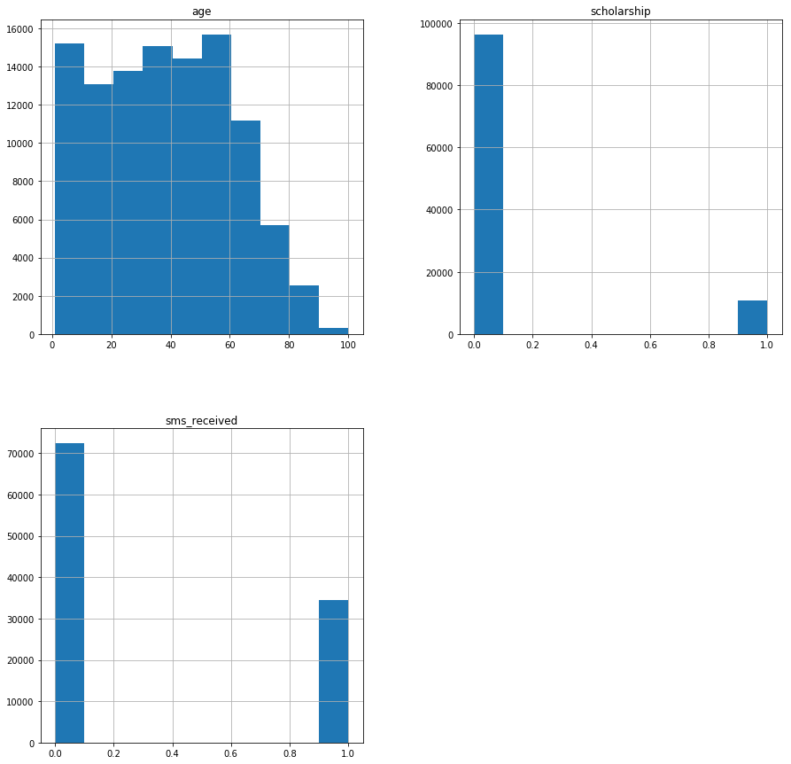

```python
df.hist(figsize=(15,15));
```

```python
#Checking number of patients that show for their scheduled appointments or did not show
pd.DataFrame(df.no_show.value_counts())
```

|  | no_show |
| --- | --- |
| No | 85303 |
| Yes | 21677 |

```python
#Checking counts of gender of the patients
pd.DataFrame(df.gender.value_counts())
```

|  | gender |
| --- | --- |
| F | 70111 |
| M | 36869 |

```python
bygender=df.groupby("gender").no_show.value_counts()
bygender
```

```
gender  no_show
F       No         55839
        Yes        14272
M       No         29464
        Yes         7405
Name: no_show, dtype: int64
```

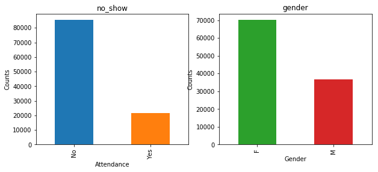

```python
#Checking counts in our dataset with bar chart
plt.figure(figsize=(10,4))
plt.subplot(1,2,1);
df.no_show.value_counts().plot(kind='bar',title='Patients showing for appointments or not',color=['C0','C1']);
plt.xlabel('Attendance')
plt.ylabel('Counts')
plt.title('no_show');

plt.subplot(1,2,2);
df.gender.value_counts().plot(kind='bar',title='Gender of the patients',color=['C2','C3']);
plt.xlabel('Gender')
plt.ylabel('Counts')
plt.title('gender');
```

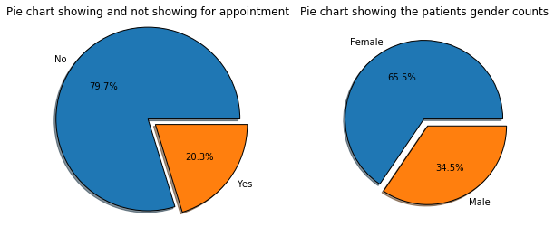

```python
#Checking counts in our dataset with pie chart for no-show and gender variables
plt.figure(figsize=(10,4))
plt.subplot(1,2,1);
noshow_values=[85303,21677]
noshow_labels=["No","Yes"]
plt.axis("equal")
plt.title("Pie chart showing and not showing for appointment")
plt.pie(noshow_values,labels=noshow_labels,radius=1.0,autopct='%0.1f%%',shadow=True,explode=[0,0.1],wedgeprops={'edgecolor':'black'});

plt.subplot(1,2,2);
gender_values=[70111,36869]
gender_labels=["Female","Male"]
plt.axis("equal")
plt.title("Pie chart showing the patients gender counts")
plt.pie(gender_values,labels=gender_labels,radius=1.0,autopct='%0.1f%%',shadow=True,explode=[0,0.1],wedgeprops={'edgecolor':'black'});
```

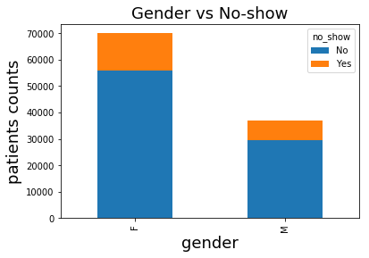

```python
bygender.unstack().plot(kind='bar',stacked=True);
plt.title('Gender vs No-show',fontsize=18)
plt.xlabel('gender',fontsize=18)
plt.ylabel('patients counts',fontsize=18);
```

### Research Question 2 Is there a relationship between age with the patient showing or not for appointment?

```python
#Checking summary statistics of the age column
df['age'].describe()
```

```
count    106980.000000
mean         38.311311
std          22.459144
min           1.000000
25%          19.000000
50%          38.000000
75%          56.000000
max         100.000000
Name: age, dtype: float64
```

```python
#Checking the overall counts of male and female in the dataset
pd.DataFrame(df.gender.value_counts())
```

|  | gender |
| --- | --- |
| F | 70111 |
| M | 36869 |

```python
#I am converting numerical variable to categorical variable using pandas' cut function
#Using the categories
#'18-25' for young adults, '25-35' for adults, '35-45' for middle aged, '45-115' for old adults
df['ageGroup']=pd.cut(df.age,[18,25,35,45,115],labels=['young adults', 'adults', 'middle aged', 'old adults'])
df['ageGroup'].head()
```

```
0    old adults
1    old adults
2    old adults
3           NaN
4    old adults
Name: ageGroup, dtype: category
Categories (4, object): [young adults < adults < middle aged < old adults]
```

```python
#Checking the overall counts of patients age categorising them into age groups in the dataset
pd.DataFrame(df.ageGroup.value_counts())
```

|  | ageGroup |
| --- | --- |
| old adults | 42934 |
| middle aged | 14582 |
| adults | 14404 |
| young adults | 9733 |

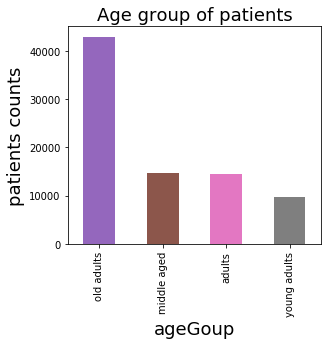

```python
#Plotting the age Group on a bar chart
plt.figure(figsize=(10,4))
plt.subplot(1,2,1);
df.ageGroup.value_counts().plot(kind='bar',color=['C4','C5','C6','C7']);
plt.title('Age group of patients',fontsize=18)
plt.xlabel('ageGoup',fontsize=18)
plt.ylabel('patients counts',fontsize=18);
```

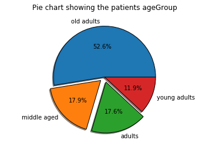

```python
#Visualizing patients age by ageGroup using pie chart
ageGroup_values=[42934,14582,14404,9733]
ageGroup_labels=["old adults","middle aged","adults","young adults"]
plt.axis("equal")
plt.title("Pie chart showing the patients ageGroup")
plt.pie(ageGroup_values,labels=ageGroup_labels,radius=1.0,autopct='%0.1f%%',shadow=True,explode=[0,0.1,0.1,0],wedgeprops={'edgecolor':'black'});
```

```python
#Checking the relationship between ageGroup and the dependent variable no_show using a stacked bar chart
byageGroup=df.groupby("ageGroup").no_show.value_counts()
byageGroup
```

```
ageGroup      no_show
young adults  No          7262
              Yes         2471
adults        No         11122
              Yes         3282
middle aged   No         11500
              Yes         3082
old adults    No         35800
              Yes         7134
Name: no_show, dtype: int64
```

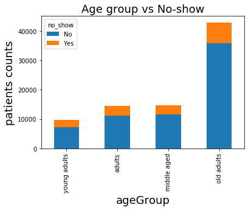

```python
byageGroup.unstack().plot(kind='bar',stacked=True);
plt.title('Age group vs No-show',fontsize=18)
plt.xlabel('ageGroup',fontsize=18)
plt.ylabel('patients counts',fontsize=18);
```

## Research Question 3 Is there a relationship between sms received with the patient showing or not for appointment?

```python
# #Checking the overall counts of patients who receive sms and patients who did not after making an appointment
pd.DataFrame(df.sms_received.value_counts())
```

|  | sms_received |
| --- | --- |
| 0 | 72396 |
| 1 | 34584 |

```python
#Checking the relationship between sms_received and the dependent variable no_show using summary statistics and a stacked bar chart
bysms=df.groupby("sms_received").no_show.value_counts()
bysms
```

```
sms_received  no_show
0             No         60287
              Yes        12109
1             No         25016
              Yes         9568
Name: no_show, dtype: int64
```

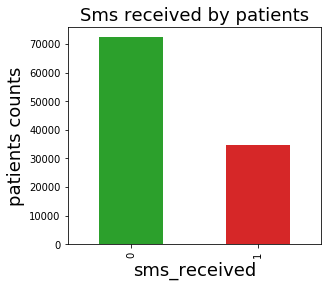

```python
#Checking counts of sms received with a visual
plt.figure(figsize=(10,4))
plt.subplot(1,2,1);
df.sms_received.value_counts().plot(kind='bar',color=['C2','C3']);
plt.title('sms_received')
plt.title('Sms received by patients',fontsize=18)
plt.xlabel('sms_received',fontsize=18)
plt.ylabel('patients counts',fontsize=18);
```

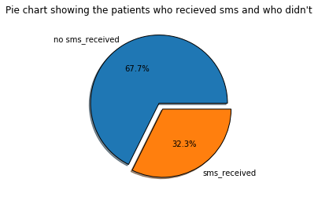

```python
#Visualizing patients who received sms and who didn't using pie chart
sms_values=[72396,34584]
sms_labels=["no sms_received","sms_received"]
plt.axis("equal")
plt.title("Pie chart showing the patients who recieved sms and who didn't")
plt.pie(sms_values,labels=sms_labels,radius=1.0,autopct='%0.1f%%',shadow=True,explode=[0,0.1],wedgeprops={'edgecolor':'black'});
```

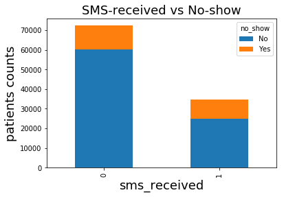

```python
#The relationship between sms_received and no_show
bysms.unstack().plot(kind='bar',stacked=True);
plt.title('SMS-received vs No-show',fontsize=18)
plt.xlabel('sms_received',fontsize=18)
plt.ylabel('patients counts',fontsize=18);
```

##### This statistics and visual shows that there is a relationship between sms_recived and no_show

# Research Question 4 Is there a relationship between scholarship with the patient showing or not for appointment?

```python
# #Checking the overall counts of patients that were awarded a scholarship and who weren't
pd.DataFrame(df.scholarship.value_counts())
```

|  | scholarship |
| --- | --- |
| 0 | 96171 |
| 1 | 10809 |

```python
#Checking the relationship between scholarship and the dependent variable no_show using summary statistics and a stacked bar chart
bysch=df.groupby("scholarship").no_show.value_counts()
bysch
```

```
scholarship  no_show
0            No         77065
             Yes        19106
1            No          8238
             Yes         2571
Name: no_show, dtype: int64
```

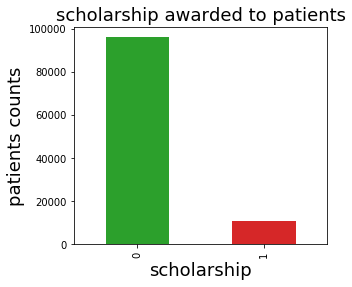

```python
#Checking counts of scholarship with a visual(bar chart)
plt.figure(figsize=(10,4))
plt.subplot(1,2,1);
df.scholarship.value_counts().plot(kind='bar',color=['C2','C3']);
plt.title('scholarship')
plt.title('scholarship awarded to patients',fontsize=18)
plt.xlabel('scholarship',fontsize=18)
plt.ylabel('patients counts',fontsize=18);
```

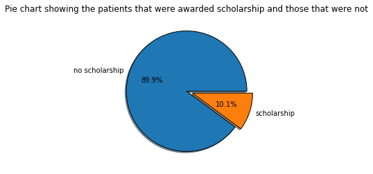

```python
#Visualizing patients that were awarded scholarship and those that were not using pie chart
scholar_values=[96171,10809]
scholar_labels=["no scholarship","scholarship"]
plt.axis("equal")
plt.title("Pie chart showing the patients that were awarded scholarship and those that were not")
plt.pie(scholar_values,labels=scholar_labels,radius=1.0,autopct='%0.1f%%',shadow=True,explode=[0,0.1],wedgeprops={'edgecolor':'black'});
```

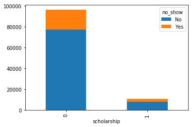

```python
#The relationship between sms_received and no_show

bysch.unstack().plot(kind='bar',stacked=True);
```

## LIMITATION

#### The limitation while doing the analysis was that the data was a dirty data, and i had to clean it to make it very suitable fo analysis; so as to get a correct answer during the analysis

#### I also changed the column names using lower case and underscore for consistency

```python
from subprocess import call
call(['python', '-m', 'nbconvert', 'PROJECT TWO_Investigate_a_Dataset average'])
```

```
255
```